# Markdown and Git

## Course Plan

- R Projects
- Markdown basics
- Git & Github
- Creating a blog & website with R and github
- Automating R Markdown
- Writing a Book with bookdown
- Creating interactive apps with R shiny

## RStudio Project

- Often have many files associated with an analysis
- With multiple analyses things get cluttered

## RStudio Project

- Often have many files associated with an analysis
- With multiple analyses things get cluttered
- Want to associate different
  - environments
  - histories
  - working directories
  - source documents

  with each analysis
- Can use “Project” feature in R Studio

## RStudio - Project

- Easy to create! Use an existing folder or create one:

[figure not shown]

- Place all files for that analysis in that directory

## RStudio - Project

Create two new projects (with new empty folders):

- One called ‘github_website’
- One called ‘automation_of_markdown’

(We’ll also create one later from git.)

- On creation select the `renv` option

## RStudio - Project

- Let’s look at project options via `tools --> Project options`
- Switch between projects with the upper right menu
- Modify and save the project. Note the differing behavior of your R sessoin depending on your project options
- Open the .Rproj file in notepad

## Markdown Basics

- Vital to make your work reproducible!
- Traditional documentation through comments (`#` in R) in script
- May have heard of [JUPYTER](http://jupyter.org/) notebooks
- R Markdown - built in notebook for R studio (a program that weaves word processing and code)

## Creating an R Markdown Document

- Work in your ‘github_website’ project
- Create a new markdown doc via menus and let’s explore it!

[figure not shown]

## Markdown **Verbage**

- May have heard of HTML (HyperText Mark-up Language)
  - Write plain text that the browser interprets and renders

## Markdown **Verbage**

- May have heard of HTML (HyperText Mark-up Language)
  - Write plain text that the browser interprets and renders
- Markdown is a specific markup language
  - Easier syntax
  - Not as powerful
- Any plain text file can be used (.Rmd extension associates it with R Studio)

## R Markdown

R Markdown file contains three important types of content:

1. (Optional) YAML header surrounded by `---`s
2. Chunks of R code
3. Text mixed with simple text formatting instructions

## R Markdown - **YAML Header**

- Define settings for document

```
---
title: "Untitled"
author: "First Last"
date: "xxxx"
output: html_document
---
```

- CTRL/CMD + Shift + k **knits** (creates the output document) via this info
- Can also knit via the little arrow to knit to a different format
- Can knit via the `rmarkdown::render()` function

## R Markdown - **Code Chunks**

- Below YAML header: ‘r chunk’

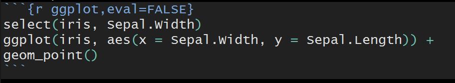

- Start code chunk by typing ```{r} out or with CTRL/CMD + Alt/Option + I
- Code will be executed when document is created
- Can specify options on individual code chunks

## R Markdown - **Syntax**

- Below code chunk is plain text with markdown sytnax

```
## R Markdown

This is an R Markdown document. Markdown is a simple formatting syntax
for authoring HTML, PDF, and MS Word documents. For more details on
using R Markdown see <http://rmarkdown.rstudio.com>.

When you click the **Knit** button a document will be generated that
includes both content as well as the output of any embedded R code
chunks within the document.
```

- When file created, “##” becomes a header, “<…>” a link, and `**Knit**` bold font

## R Markdown - **Syntax**

## Markdown

Syntax is really easy to learn via the [Cheat sheet](https://www.rstudio.com/wp-content/uploads/2015/03/rmarkdown-reference.pdf)

Quick look at the following:

- Markdown syntax
- Code chunks and their options
- Changing type of output

## **R Markdown syntax**

- `# Header 1` becomes a large font header
- `## Header 2` becomes a slightly smaller font header
- Goes to 6 headers
  - Use of headers can automatically create a Table of Contents!
- `**bold**` **and** `__bold__`
- `code` becomes `code`

## **R Markdown syntax**

- Can do lists: be sure to end each line with two spaces!
  - Indent sub lists four spaces

```
* unordered list
* item 2
    + sub-item 1
    + sub-item 2

1. ordered list
2. item 2
    + sub-item 1
    + sub-item 2
```

- unordered list
- item 2
  - sub-item 1
  - sub-item 2
1. ordered list
2. item 2
   - sub-item 1
   - sub-item 2

## **Code chunks and their options**

- Any R code can go into a chunk
- Usually a ‘set-up’ chunk at the top to read in packages, set global chunk options, etc.
- Chunks evaluate sequentially (can use output from prior chunk) that is saved as an R object - let’s check that!

## **Code chunks and their options**

- Many options depending on chunk purpose!
- Can hide/show code with `echo = FALSE/TRUE`
- Can choose if code is evaluated with `eval = TRUE/FALSE`
- `message = TRUE/FALSE` and `warning = TRUE/FALSE` can turn on/off displaying messages/warnings

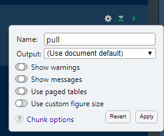

## Documenting with Markdown

- R Markdown = Digital “Notebook”: Program that weaves word processing and code.
- Designed to be used in three ways (R for Data Science)
  - Communicating to decision makers (focus on conclusions not code)
  - Collaborating with other data scientists (including future you!)
  - As environment to do data science (can evaluate and edit/reevaluate code chunks and document what you did and what you were thinking)

## **Changing type of output**

R Markdown really flexible!

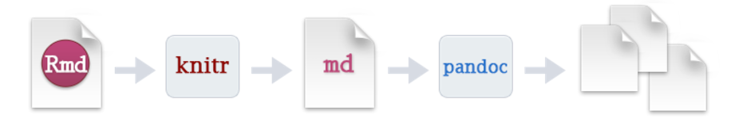

## **Changing type of output**

R Markdown really flexible!

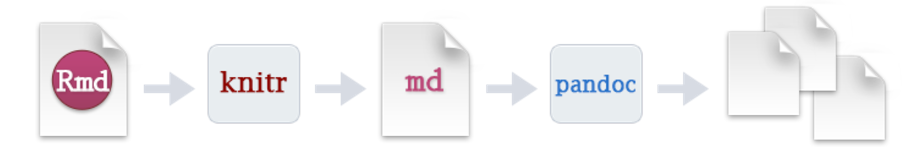

- Change output type in the YAML header and use CTRL/CMD + Shift + k
- knit via the menu
- Use code explicity:  
  `rmarkdown::render("file.Rmd", output_format = "html_document")`
- Outputting to PDF requires a version of Tex. If you don’t have one, install the `tinytex` package and run `tinytex::install_tinytex()`
- Check that you can output to HTML, PDF, and Word using one of the above methods

## Other Options on Outputs

Check out [the R Markdown definitive guide](https://bookdown.org/yihui/rmarkdown/documents.html) for cool options for each type of output!

- Try to implement code folding, tabsets, and a TOC in an HTML output doc. Can you do it via `render`?
- Try to implement the kable method of printing a data frame and a TOC in a PDF. Can you do it via `render`?

## Output to multiple formats

Multiple outputs in one call:

- `rmarkdown::render("yourfile.Rmd", output_format = c("html_document", "pdf_document", "word_document")`
- You can also change the name of the output files via the `output_file` argument
- Can you get it to output three files called ‘my.html’, ‘your.pdf’, ‘their.docx’ with one function call?
- Let’s try it! (Note: You can’t specify options when rendering to multiple formats)

## R Markdown

- Great for document your code/thoughts and for sharing your analyses easily!
- Next, we’ll learn about git/github and how RStudio can work with them
- A similar Markdown language is used to render documents on github so we’ve already learned enough to create some basic webpages too :)

## What are git and github?

Ideally we want to document our process, easily collaborate, and widely share our work

- To make our workflow for a project reproducible, ideally we would save different versions of our analysis, write-up, etc. along the way
- git is a version control software that easily allows multiple users to work on the **same** project. It simply tracks the changes that we `commit` to the files.
- No more finaldoc.pdf, finalfinaldoc.pdf, finaldoc08_11_21.pdf, …
- github is a hosting service that allows us to do Git-based projects on the internet and share them widely!

## Tracking: Basic idea

- Create a repository on github.com (files saved remotely)
- When you (or collaborator) want to work on it, you `clone` the repo locally (or `pull` the files down to update it)
- You work, save things, etc.
- Your work was good! Nice. Now you want to `add` your modified/new files to the repo so other can use them.
- You then stage your `commit` (i.e. prepare everything to send back to the remote repo)
- You `push` your local committed changes up the the repo on github
- Everyone has access to it now!

## Collaboration: Basic idea

Everyone can work on the same branch and update as needed (sometimes there will be merge conflicts, covered shortly)

- People often `fork` the repo or create their own `branch` to work on, rather than modify the main repository
- Perhaps the main repo is being used for something and you don’t want to `push` up your changes until they are tested or the new ‘feature’ is debugged
- You work on your branch using the idea from the previous slide
- Once happy with everything, you do a `merge` request to combine your modified repo with the main repo branch

## Visual

(from https://git.logikum.hu)

Each circle represents a ‘commit’ to that repository/branch (all version of files at each commit are kept!)

[figure not shown]

## Wow - How do we get started??

Let’s look at an [example repo](https://github.com/jbpost2/TeachingWithR) and the commits done/how it is tracked!

- Start with basic workflow with yourself by creating a blog on github!

## Blog Instructions

- Sign into github.com and then go to [this repo](https://github.com/barryclark/jekyll-now)
- Click `fork` in the top right corner. This will give you a copy of this repo under your account! Under settings, rename the repo to yourname.github.io
- Visit https://yourgithubusername.github.io to see the default blog page (i.e. you already have a blog :)

## Blog Instructions

- Let’s make some changes! Click on the `_posts` folder. Edit the file you see there by clicking on the name. You can then click on the pencil in the right hand header for the file display.
  - Change the file name to today’s date.
  - Update the title in the YAML header.
  - Use the markdown syntax we learned to write a short paragraph or two (no R code chunks though!)
  - Write a commit message under ‘Commit changes’ and click the green button at the bottom
- It may take 2 minutes but visit https://yourgithubusername.github.io again to see the changes.

## Cloning the repo

- To follow our previous idea (and to start doing this with R), we really don’t want to use the web interface
- We can `clone` the repo (i.e. download the entire repo locally)
- Repo main page has a green button. Click on that.
  - Can download a zip and unzip it to an appropriate folder
  - Can clone via the URL and terminal or RStudio
- Open RStudio, go to new project, from Version Control, choose Git, and paste in the repo link. Select a directory to save this in and hit Create project!
- Now have the files locally!

## Update check

We need to make sure RStudio and github can communicate. Do the following:

- Go to the `Git` tab in your `Environment` area
- You should see some files there. These are the ones that have changed from the remote repo (the one on github)
- Here you can add files that you’d like to commit up to the remote repo
- Click on all of the boxes (equivalent to `git add -A`) and click the `Commit` button

## Update check

- This brings up a window that allows you to compare changes. If you are happy you can put a commit message in the box in the top right and click the commit button (equivalent to `git commit -m "message"`)
- Hit close on the window (you should see no errors, just a message about the commit)
- Now click the push button in the top right (equivalent to `git push`)
- You should be prompted to log-in in some way. Do so!
- Go to your repo on gitub.com and see the changes!

## Alternative to the Menu

When working by myself on a repo, I’m not worried about merge conflicts with other people’s changes. As such, my workflow is as follows:

- Open the appropriate project in RStudio
- Go to the Terminal (switched to Bash) and type `git pull` (or use the git tab)
- Work… at a good spot for saving, back to the terminal
- Type `git add -A` to add all files that have been modified
- Type `git commit -m "Message"` to stage a commit
- Type `git push` to push the local changes to the remote repo

## Try Out the Workflow

- Go to your blog repo and make a change via the web interface
- Your local repo is no longer up to date! (Type `git status` in the terminal to check). You’ll need to pull down the changes.
- Now, let’s update from RStudio!
- Update the about page of your blog by editing ‘about.md’. Make changes like before and commit!
- Push up the changes. In 2-3 minutes you should see the About page updates :)

## Creating a Repo

Let’s create a repo with our already created ‘github_website’ project

- Go to github.com and create a repo with that name (Use the + in the top right corner - don’t initiate a git ignore file)
- Open the github_website project we worked on earlier
- Go to Tools –> Project Options –> Git (restart R as requested)
- Now in the terminal do the following:
  - `git remote add origin [paste the clone link here]` (initiate the tracking of the project on github)
  - `git pull origin main` (download all remote files)
  - `git push -u origin main` (track changes on this machine)
- Add, commit, and push your files up!

## Creating a website

Very easy! Two steps:

- Enable github pages in your repo settings (on github.com)
- Create a README.Rmd file. Change the output type to `github_document`
- Write whatever R code you want, add, commit, and push up your changes
- Now you’ll have a site like https://jbpost2.github.io/github_website/

## Automating R Markdown

Let’s take a break from git!

- Other markdown functionality: Using `parameters`
- Can be added to the YAML header and can be used to automate reports!
- Suppose we are dealing with a football box score data set

```r
NFLData <- read_csv("https://www4.stat.ncsu.edu/~online/datasets/scoresFull.csv")
NFLData
```

```
## # A tibble: 3,471 x 82
##   week  date  day   season awayTeam     AQ1   AQ2   AQ3   AQ4   AOT  AOT2 AFinal
##   <chr> <chr> <chr>  <dbl> <chr>      <dbl> <dbl> <dbl> <dbl> <dbl> <dbl>  <dbl>
## 1 1     5-Sep Thu     2002 San Franc~     3     0     7     6    -1    -1     16
## 2 1     8-Sep Sun     2002 Minnesota~     3    17     0     3    -1    -1     23
## 3 1     8-Sep Sun     2002 New Orlea~     6     7     7     0     6    -1     26
## 4 1     8-Sep Sun     2002 New York ~     0    17     3    11     6    -1     37
## 5 1     8-Sep Sun     2002 Arizona C~    10     3     3     7    -1    -1     23
## # ... with 3,466 more rows, and 70 more variables: homeTeam <chr>, HQ1 <dbl>,
## #   HQ2 <dbl>, HQ3 <dbl>, HQ4 <dbl>, HOT <dbl>, HOT2 <dbl>, HFinal <dbl>,
## #   stadium <chr>, startTime <time>, toss <chr>, roof <chr>, surface <chr>,
## #   duration <dbl>, attendance <chr>, weather <chr>, vegasLine <chr>, OU <chr>,
## #   AfirstDowns <dbl>, AnetPassYds <dbl>, AtotalYds <dbl>, Aturnovers <dbl>,
## #   AtotalPlays <dbl>, HfirstDowns <dbl>, HnetPassYds <dbl>, HtotalYds <dbl>,
## #   Hturnovers <dbl>, HtotalPlays <dbl>, OUvalue <dbl>, OUresult <chr>,
## #   awayRushAtt <dbl>, awayRushYds <dbl>, awayRushTD <dbl>, awayPassComp <dbl>,
## #   awayPassAtt <dbl>, awayPassYds <dbl>, awayPassTD <dbl>, awayPassInt <dbl>,
## #   awayTimesSacked <dbl>, awaySackYdsLost <dbl>, awayFum <dbl>,
## #   awayFumLost <dbl>, awayNumPen <dbl>, awayPenYds <dbl>, away3rdConv <dbl>,
## #   away3rdAtt <dbl>, away4thConv <dbl>, away4thAtt <dbl>, awayTOP <dbl>,
## #   homeRushAtt <dbl>, homeRushYds <dbl>, homeRushTD <dbl>, homePassComp <dbl>,
## #   homePassAtt <dbl>, homePassYds <dbl>, homePassTD <dbl>, homePassInt <dbl>,
## #   homeTimesSacked <dbl>, homeSackYdsLost <dbl>, homeFum <dbl>,
## #   homeFumLost <dbl>, homeNumPen <dbl>, homePenYds <dbl>, home3rdConv <dbl>,
## #   home3rdAtt <dbl>, home4thConv <dbl>, home4thAtt <dbl>, homeTOP <dbl>,
## #   HminusAScore <dbl>, homeSpread <dbl>
```

## Markdown Parameters

Parameters can be added to the YAML header

```
title: "NFL Reports"
author: "Justin Post"
output: html_document
params:
      team: "Pittsburgh Steelers"
```

- Can ‘Knit with parameters’
- In .Rmd, access via `params$team`
- Example: Let’s open up the [NFL.Rmd document](https://jbpost2.github.io/R-for-Automating-Workflow-Sharing-Work/slides/NFL.Rmd)

## Parameters

May want to create a similar document/output for all 32 teams

- Utilize code method for knitting the document

```r
rmarkdown::render("NFL.Rmd", output_file = "Cleveland Browns.html",
                                    params = list(team = "Cleveland Browns"))
```

- Would create same document using the Cleveland Browns data

## Parameters

Plan:

- Create data frame that has
  - file names to output to
  - list with each team name for using in `render()`

For one team the row would be (last column’s value is really a list with one value in it)

```
##                output_file                team
## 1 Pittsburgh Steelers.html Pittsburgh Steelers
```

## Parameters

```r
#get unique teams
teamIDs <- unique(NFLData$awayTeam)
#create filenames
output_file <- paste0(teamIDs, ".html")
#create a list for each team with just the team name parameter
params = lapply(teamIDs, FUN = function(x){list(team = x)})

#put into a data frame
reports <- tibble(output_file, params)
```

## Parameters

```r
reports
```

```
## # A tibble: 32 x 2
##   output_file              params
##   <chr>                    <list>
## 1 San Francisco 49ers.html <named list [1]>
## 2 Minnesota Vikings.html   <named list [1]>
## 3 New Orleans Saints.html  <named list [1]>
## 4 New York Jets.html       <named list [1]>
## 5 Arizona Cardinals.html   <named list [1]>
## # ... with 27 more rows
```

## Parameters

Now knit using `apply()` or via `purrr::pwalk()`

```r
library(rmarkdown)
#need to use x[[1]] to get at elements since tibble doesn't simplify
apply(reports, MARGIN = 1,
            FUN = function(x){
                render(input = "files/NFL.Rmd", output_file = x[[1]], params = x[[2]])
                })

#or with pwalk (args are .l, .f, and ...)
#.l is a list of lists, .f is function, formula, or vector
pwalk(reports, render, input = "files/NFL.Rmd")
```

## Parameters

This can be done with multiple parameters.

- Nice way to automate creation
- Could put into a nice pipeline
  - Create file to update NFL data each week (scrape new data and add to .csv file)
  - Create .Rmd file that you want for each team
  - Create file to submit creation of documents with params
  - Put all into one file (say with `source`)
  - [Have that file automatically run](https://anderfernandez.com/en/blog/how-to-automate-r-scripts-on-windows-and-mac/)!

## Try it yourself!

Try to do a similar process where you use the `iris` data frame and create three separate analysis based off of the `Species` column.

- Create a parameter called `species`
- Run the following code in your markdown doc:

```r
myIris <- filter(iris, params$species)
summary(myIris)
plot(myIris)
```

- Use `apply()` or `pwalk()` to generate the three reports.

## Bookdown

- You can easily write a book using RStudio too!
- Can be done via File –> New Directory –> Book Project Using bookdown
- Instead we’ll clone [this repo](https://github.com/jbpost2/myBook) and then create an R project from a git repository
- Let’s see how to build the book!
- Chapters are just .Rmd files (named appropriately `01-intro.Rmd`) that start with a `#`

## Merging Branches

- Seems like a good idea to talk about merging branches!
- If you do a commit on your branch, you may notice something like this

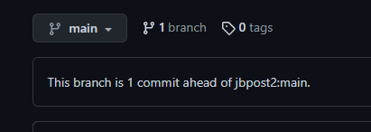

## Merging Branches

Suppose you like your commit and you think I will too!

- You can do a `pull` request

[figure not shown]

## Merging Branches

Suppose you like your commit and you think I will too!

- You can do a `pull` request

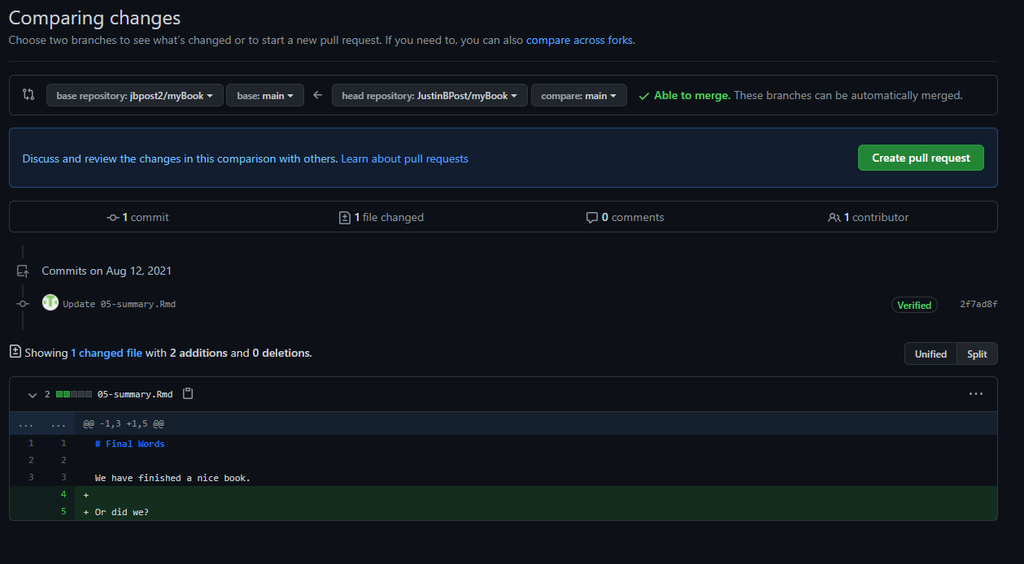

## Merging Branches

If you are lucky, there won’t be any merge conflicts.

- Allows the owner of the original repo to accept the pull request without needing to modify things
- The owner will get a notification that a pull request has been made

[figure not shown]

## Merging Branches

Owner can then investigate the request and choose whether or not to accept it or they can ask for more details

[figure not shown]

## Dealing with conflicts

- Sometimes changes requested conflict with changes already made

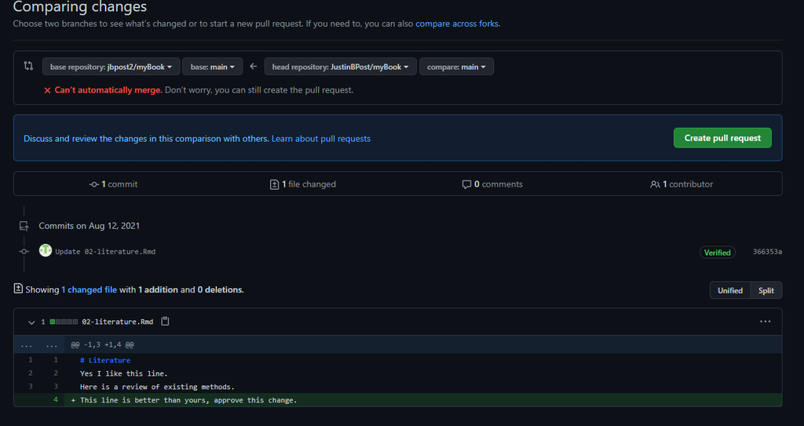

## Dealing with conflicts

Owner sees a notification about conflicts that must be resolved

[figure not shown]

## Dealing with conflicts

They can view the issues and pick which to include or to include both with a modification

`<<<<<<<` is a conflict marker

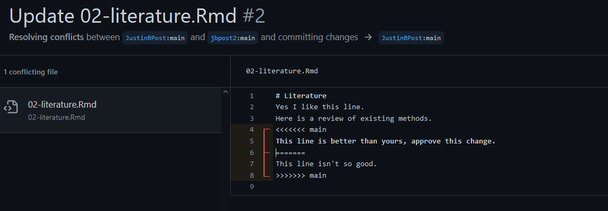

- Figure out what to do and delete the `<<< === >>>` lines

## Course Plan

- R Projects
- Markdown basics
- Git & Github
- Creating a blog & website with R and github
- Automating R Markdown
- Writing a Book with bookdown
- Creating interactive apps with R shiny